# Tissue specificity index analysis - tau

Deisiany

2024-01-13

# read in data

For Tissue specificity index analysis - tau - we will use the 133 genes which had average expression across all tissues equal or greater than 2, and was used in our PCA analysis.

```r
# Load full genes
data <- read_csv("Tau_133_genes_with_expression_across_tissues_are_greater_than_2_SoyARCs.csv")
data <- data %>% select(-c(Class, Clade, expr_median))
```

# Calculate the component value

X(^) = Xi/ max(Xi) for 1<=i <=n

```r
# lets start by assigning our data to df
max_component_df <- data

for (Xi in 1:nrow(max_component_df)) {
  max_component_df[Xi, 4:17] <- max_component_df[Xi, 4:17] / max(max_component_df[Xi, 4:17], na.rm = TRUE)
}

max_component_df
```

```
## # A tibble: 133 × 17
##    `Transcript ID`   heatmap_label      Family     AM    OF   IAM    IBM RootTip
##    <chr>             <chr>              <chr>   <dbl> <dbl> <dbl>  <dbl>   <dbl>
##  1 Glyma.01G002100.1 Glyma.01G002100|G… ARF    0.816  0.890 0.797 0.945   0.486
##  2 Glyma.01G019400.1 Glyma.01G019400|G… IAA    0.382  0.718 0     0.140   0.349
##  3 Glyma.01G019400.2 Glyma.01G019400|G… IAA    0.175  0     0.266 0.339   0.0983
##  4 Glyma.01G019400.3 Glyma.01G019400|G… IAA    0.254  0.404 0.234 0.301   0.182
##  5 Glyma.01G098000.3 Glyma.01G098000|G… IAA    0.396  0.298 0.311 0.559   0.190
##  6 Glyma.01G103500.1 Glyma.01G103500|G… ARF    0.694  0.214 0.420 0.839   0.146
##  7 Glyma.02G000500.1 Glyma.02G000500|G… IAA    0.252  0.315 0.137 0.114   0.271
##  8 Glyma.02G065300.1 Glyma.02G065300|G… AFB/T… 0.522  0.424 0.506 0.772   0.251
##  9 Glyma.02G142500.3 Glyma.02G142500|G… IAA    0.0277 1     0.138 0.0538  0.0816
## 10 Glyma.02G142600.1 Glyma.02G142600|G… IAA    0.0541 1     0.243 0.266   0.238
## # ℹ 123 more rows
## # ℹ 9 more variables: Cotyledon <dbl>, Hypocotyl <dbl>, SAM6D <dbl>,
## #   SAM17D <dbl>, SAM38D <dbl>, Callus <dbl>, Leaf <dbl>, Root <dbl>,
## #   Nodule <dbl>
```

```r
# Calculate Tau (Tissue Specificity Index) for each gene
tau_df <- max_component_df

tau_df$tau <- numeric(nrow(tau_df))  # Create an empty column

for (i in 1:nrow(tau_df)) {
  tau_df$tau[i] <- sum(1 - tau_df[i, 4:17]) / 13
}

# write_csv(tau_df, "tau_df_contains_maximal_component_values.csv")
```

```r
(tau_df_values <- tau_df %>% select(`Transcript ID`, heatmap_label, tau))
```

```
## # A tibble: 133 × 3
##    `Transcript ID`   heatmap_label                   tau
##    <chr>             <chr>                         <dbl>
##  1 Glyma.01G002100.1 Glyma.01G002100|GmARF7/19_F.1 0.376
##  2 Glyma.01G019400.1 Glyma.01G019400|GmIAA8-9-B.1  0.615
##  3 Glyma.01G019400.2 Glyma.01G019400|GmIAA8-9-B.2  0.796
##  4 Glyma.01G019400.3 Glyma.01G019400|GmIAA8-9-B.3  0.800
##  5 Glyma.01G098000.3 Glyma.01G098000|GmIAA8-9-D.3  0.643
##  6 Glyma.01G103500.1 Glyma.01G103500|GmARF9_A.1    0.711
##  7 Glyma.02G000500.1 Glyma.02G000500|GmIAA1-4-D.1  0.831
##  8 Glyma.02G065300.1 Glyma.02G065300|GmAFB2/3_C.1  0.619
##  9 Glyma.02G142500.3 Glyma.02G142500|GmIAA16-F.3   0.944
## 10 Glyma.02G142600.1 Glyma.02G142600|GmIAA1-4-H.1  0.895
## # ℹ 123 more rows
```

```r
#write_csv(tau_df_values, "tau_df_values.csv")
```

# tau values greater than .80 are a cut off utilized in the literature to denote tissues specificity.

```r
tau_greater_80 <- tau_df_values[tau_df_values$tau >= 0.80, ]

#write_csv(tau_greater_80, "tau_greater_80.csv")
```

Here https://rdrr.io/github/roonysgalbi/tispec/f/vignettes/UserGuide.Rmd we can access some useful information about the tau measurement. And these papers also mention these same analysis: https://academic.oup.com/bioinformatics/article/21/5/650/220059#394030419 https://academic.oup.com/bib/article/18/2/205/2562739?login=true https://www.ncbi.nlm.nih.gov/pmc/articles/PMC7791837/#CR75

# tau distribution for all 14 tissues

```r
tau_df <- read_csv( "tau_df_contains_maximal_component_values.csv")
```

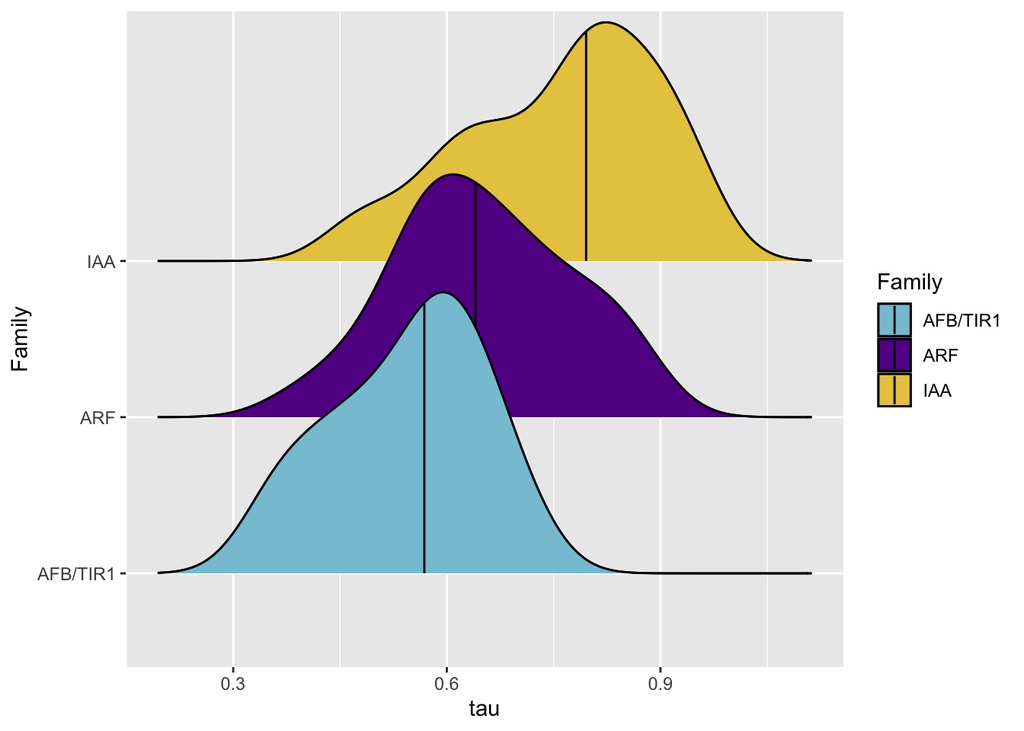

```r
library(ggplot2)
library(ggridges)
library(dplyr)

# Calculate medians
medians <- tau_df %>%
  group_by(Family) %>%
  summarise(median_tau = median(tau))

ggplot(tau_df, aes(x = tau, y = Family, fill = Family)) +
  scale_fill_manual(values = c("#86C5D8", "#620093", "#E7C94C")) +
  ggridges::geom_density_ridges() +
  ggridges::stat_density_ridges(
    quantile_lines = TRUE,
    quantiles = 2) +
  coord_cartesian(ylim = c(1, length(unique(tau_df$Family)) + 1))
```

# statistical testing

```r
stats_tau <- tau_df %>% select(Family, tau)

summary(stats_tau)
```

```
##     Family               tau
##  Length:133         Min.   :0.3506
##  Class :character   1st Qu.:0.5807
##  Mode  :character   Median :0.6743
##                     Mean   :0.6828
##                     3rd Qu.:0.7964
##                     Max.   :0.9559
```

```r
library(doBy)
summaryBy(tau ~ Family,
          data = stats_tau,
          FUN = median)
```

```
## # A tibble: 3 × 2
##   Family   tau.median
##   <chr>         <dbl>
## 1 AFB/TIR1      0.568
## 2 ARF           0.640
## 3 IAA           0.796
```

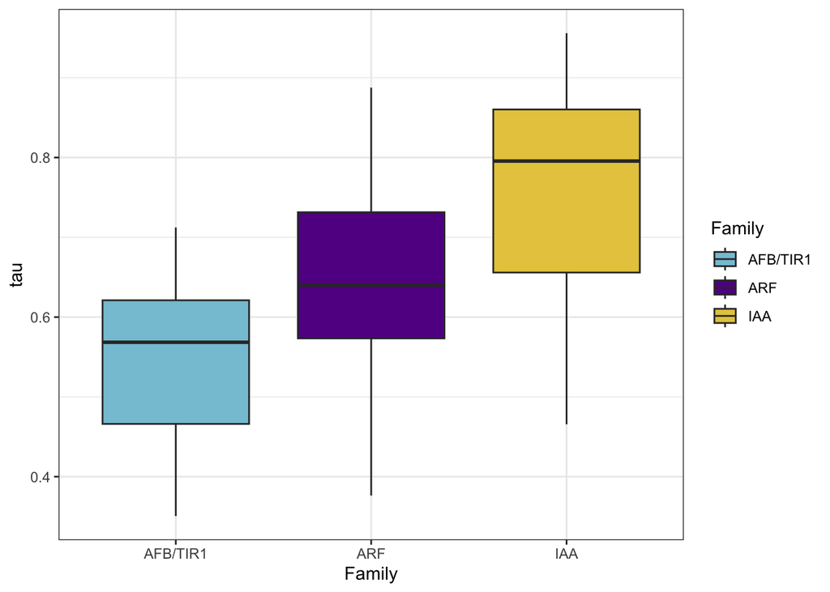

```r
ggplot(stats_tau) +
  aes(x = Family, y = tau, fill = Family) +
  geom_boxplot() +
  theme(legend.position = "none") +
  scale_fill_manual(values = c("#86C5D8", "#620093", "#E7C94C")) +
  theme_bw()
```

The null and alternative hypotheses of the Kruskal-Wallis test are:

𝐻0: The 3 families are equal in terms of tau 𝐻1: At least one Family is different from the other 2 Families in terms of tau

# kruskal test

```r
kruskal.test(tau ~ Family, data = stats_tau)
```

```
##
##  Kruskal-Wallis rank sum test
##
## data:  tau by Family
## Kruskal-Wallis chi-squared = 32.403, df = 2, p-value = 9.201e-08
```

based on the kruskal test we reject the null hypothesis and conclude that at least one family is different in terms of tau values.

# Post-hoc test

```r
pairwise.wilcox.test(stats_tau$tau, stats_tau$Family,
  p.adjust.method = "holm"
)
```

```
##
##  Pairwise comparisons using Wilcoxon rank sum test with continuity correction
##
## data:  stats_tau$tau and stats_tau$Family
##
##     AFB/TIR1 ARF
## ARF 0.0042   -
## IAA 1.1e-05  3.2e-05
##
## P value adjustment method: holm
```

all 3 families are differ significantly in terms of tau, p<0.05

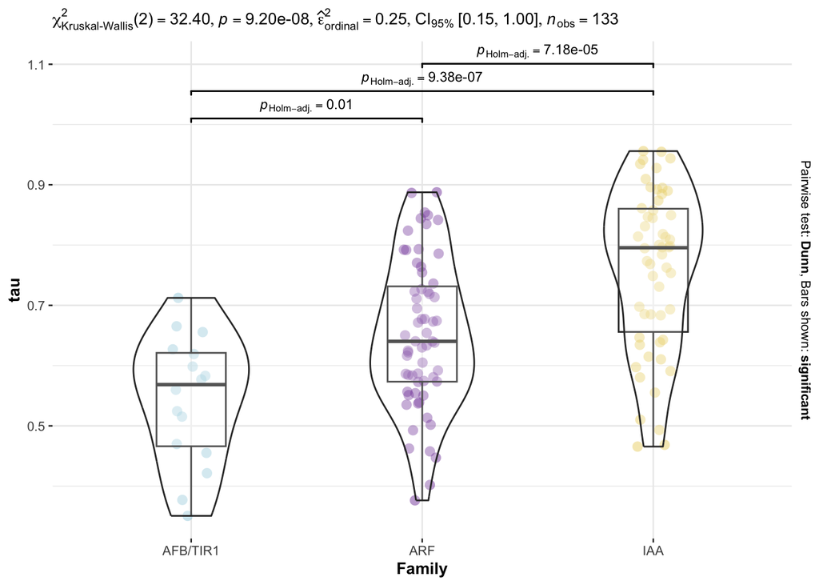

```r
# install newest version of ggplot2 and load all packages
#library(remotes)
# remotes::install_version("ggplot2", version = "3.5.1")
#install.packages("ggstatsplot")
library(ggplot2)
library(ggstatsplot)
ggstatsplot::ggbetweenstats(
  data = stats_tau,
  x = Family,
  y = tau,
  type = "nonparametric", # ANOVA or Kruskal-Wallis
  plot.type = "box",
  pairwise.comparisons = TRUE,
  pairwise.display = "significant",
  centrality.plotting = FALSE,
  bf.message = FALSE) +
  scale_color_manual(values =
                      c("#86C5D8", "#620093", "#E7C94C"))
```

```r
ggsave("Kruskal-test-tau-values.pdf", height = 5, width = 6)
ggsave("Kruskal-test-tau-values.jpeg", height = 5, width = 6, dpi = 1000)
```

# repeat analysis removing tissues that were not used in our final analysis

Roots, callus, Inflorescence and so on, were not taken into account in our final analysis. Thus, lets repeat this without this tissues.

```r
# lets start by assigning our data to df
max_component_df_aerial <- data %>%
  select(`Transcript ID`, heatmap_label, SAM6D, SAM17D, SAM38D, AM, Cotyledon, Leaf, Hypocotyl)

for (Xi in 1:nrow(max_component_df_aerial)) {
  max_component_df_aerial[Xi, 3:9] <- max_component_df_aerial[Xi, 3:9] / max(max_component_df_aerial[Xi, 3:9], na.rm = TRUE)
}

max_component_df_aerial
```

```
## # A tibble: 133 × 9
##    `Transcript ID`   heatmap_label    SAM6D SAM17D SAM38D    AM Cotyledon   Leaf
##    <chr>             <chr>            <dbl>  <dbl>  <dbl> <dbl>     <dbl>  <dbl>
##  1 Glyma.01G002100.1 Glyma.01G00210… 0.718  0.650  0.461  0.816   0.505   0.392
##  2 Glyma.01G019400.1 Glyma.01G01940… 0.283  0.747  0.327  0.382   0.0952  1
##  3 Glyma.01G019400.2 Glyma.01G01940… 0.795  0      0.211  0.334   0.177   1
##  4 Glyma.01G019400.3 Glyma.01G01940… 0.283  0.299  0.328  0.254   0.0454  0.0695
##  5 Glyma.01G098000.3 Glyma.01G09800… 0.590  0.628  0.334  0.396   0.455   0.419
##  6 Glyma.01G103500.1 Glyma.01G10350… 0.790  1      0.488  0.694   0.0621  0
##  7 Glyma.02G000500.1 Glyma.02G00050… 0.220  0.215  0.415  0.252   0.0604  0.0656
##  8 Glyma.02G065300.1 Glyma.02G06530… 0.859  1      0.430  0.522   0.0816  0.148
##  9 Glyma.02G142500.3 Glyma.02G14250… 0.0641 0.0579 0.0650 0.128   0.00176 0.179
## 10 Glyma.02G142600.1 Glyma.02G14260… 0.220  0.352  0.130  0.321   0.436   0.541
## # ℹ 123 more rows
## # ℹ 1 more variable: Hypocotyl <dbl>
```

```r
# Calculate Tau (Tissue Specificity Index) for each gene
tau_df_aerial <- max_component_df_aerial

tau_df_aerial$tau <- numeric(nrow(tau_df_aerial))  # Create an empty column

for (i in 1:nrow(tau_df_aerial)) {
  tau_df_aerial$tau[i] <- sum(1 - tau_df_aerial[i, 3:9]) / 6
}

#write_csv(tau_df_aerial, "tau_df_values_aerial_tissues.csv")

tau_df_aerial_values <- tau_df_aerial %>% select(`Transcript ID`, heatmap_label, tau)

# Now lets select values greater than 80 again
tau_aerial_greater_80 <-
  tau_df_aerial_values[tau_df_aerial_values$tau >= 0.80, ]
```